# Wiki

Здесь будет рассказано о методе решения кубических уравнений.

### Оригинальные статьи:

- How to Solve a Cubic Equation Part 1 – The Shape of the Discriminant
- How to Solve a Cubic Equation Part 2 – The $1\overline{1}$ Case
- How to solve a Cubic Equation Part 3 – General Depression and a New Covariant
- How to Solve a Cubic Equation Part 4 – The 111 Сase
- How to Solve a Cubic Equation Part 5 – Back to Numerics

Авторство: James F. Blinn

Microsoft Research

blinn@microsoft.com

Originally published in

IEEE Computer Graphics and Applications

### Постановка задачи:

Рассмотрим многочлен третьей степени с вещественными коэффициентами:

$$f(x) = Ax^3 + Bx^2 + Cx + D = 0.\quad\quad\quad\quad(0) $$

Однако Джеймс Блинн в своих статьях рассматривает уравнение вида

$$f(x,w) = Ax^3 + Bx^2w + Cxw^2 + Dw^3 = 0,\quad\quad\quad\quad(0.1)$$

Можно заметить, что

$$f(x,1) = Ax^3 + Bx^2 \cdot 1 + Cx \cdot 1^2 + D \cdot 1^3 = Ax^3 + Bx^2 + Cx + D = f(x).$$

Параметр $w$ вводится Блинном как вторая переменная в кубическом многочлене, чтобы работать с матрицами размера $2x2$. Позже, по ходу решения, он приравнивается к единице: $w=1$.

Известно, что для многочлена третьей степени с вещественными корнями, заданного уравнением $(0)$, существует 4 возможных случая:

- "$3$" единственный действительный корень кратности 3: $$f(x) = (x-x_1)^3.$$
- "$21$" один действительный корень кратности 2 и другой действительный корень кратности 1: $$f(x) = (x-x_1)^2(x-x_2).$$
- "$111$" три различных действительных корня: $$f(x) = (x-x_1)(x-x_2)(x-x_3).$$
- "$1\overline{1}$" один действительный корень и один комплексно-сопряженный корень: $$f(x) = (x-x_1)(x^2+px+q) = (x-x_1)(x-(a+ib))(x-(a-ib)).$$

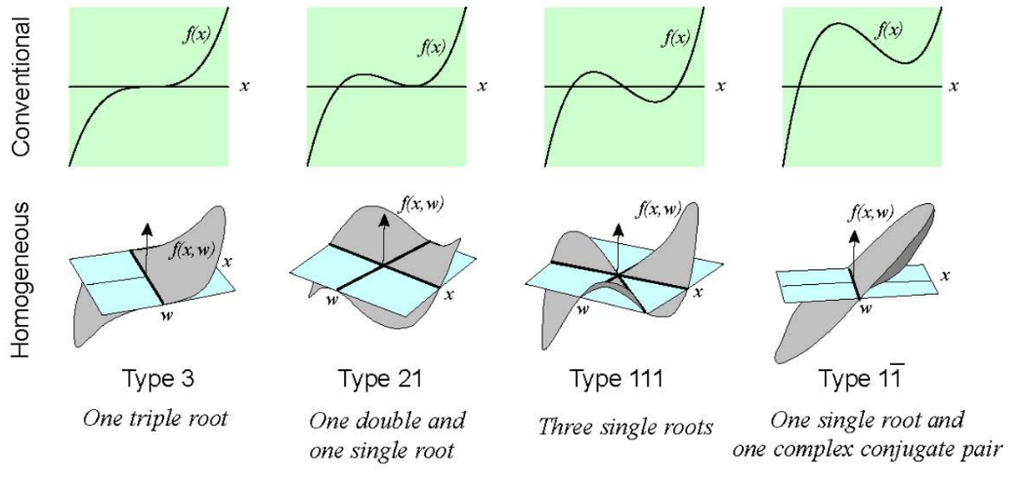

### Этапы решения:

1. depressing
- преобразование кубического многочлена с целью обнуления коэффициента $B$.
2. scaling
- сокращения общего множителя во всех коэффициентах.
- подстановка коэффициентов в уравнение syzygy.
3. solving
- рассмотрение нескольких случаев значений инварианта и поиск корней.
4. undepressing
- обратное преобразование.

### Коварианты

#### Первый ковариант

В статье [2]. (Blinn, J.F., "Inferring Transforms") было описано следующее преобразование:

$$ \begin{bmatrix} x & w \\ \end{bmatrix} = \begin{bmatrix} \tilde{x} & \tilde{w} \\ \end{bmatrix} T, \quad\quad\quad\quad(1.1)$$

где $$ T = \begin{bmatrix} t & u \\ s & v \\ \end{bmatrix}.\quad\quad\quad\quad(1.2) $$

Данное преобразование позволяет осуществить переход вектора $[x \quad w]$ из одного базиса в другой, при этом никак не меняя и не теряя корни уравнения или их кратность. То есть, любое кубическое уравнение, например, с тремя действительными корнями может быть преобразовано в другое кубическое уравнение с тремя действительными корнями.

Данное преобразование потребуется на этапе решения depressing, где нужно осуществить переход в базис, где коэффициент $\tilde{B}=0$. Пространство с базисом, где $\tilde{B}=0$ будем называть тильда-пространством.

К тому же, в статье [2] было доказано, что для любого вектора корней всегда существует матрица перехода $T$. А следовательно, мы всегда можем выполнить необходимое преобразование.

Полученные из уравнения $(1.1)$ выражения для $x$ и $w$ через $\tilde{x}$ и $\tilde{w}$ подставим в $(0.1)$ и получим матрицу перехода для вещественных коэффициентов $A,B,C,D$:

$$ \begin{bmatrix} \tilde{A} \\\tilde{B} \\\tilde{С} \\ \tilde{D} \end{bmatrix} = \begin{bmatrix} t^3 & 3t^2u & 3tu^2 & u^3 \\ t^2s & 2tus+t^2v & u^2s+2tuv & u^2v \\ ts^2 & us^2+2tsv & 2usv+tv^2 & uv^2 \\ s^3 & 3s^2v & 3sv^2 & v^3 \end{bmatrix} \begin{bmatrix} A \\B \\С \\ D \end{bmatrix}. \quad\quad\quad\quad(1.3)$$

Таким образом, получим вещественные коэффициенты $\tilde{A}, \tilde{B}, \tilde{C}, \tilde{D}$, выраженные через старые коэффициенты $A, B, C, D$.

$$\tilde{B} = t^2sA + (2tus+t^2v)B + (u^2s+2tus)C + u^2vD =$$

$$= s(t^2A + 2tuv + u^2C) + v(t^2B+2tuC+u^2D) = 0.$$

Получим, что $\tilde{B} = 0$ при

$$ s = -k(t^2B+2tuC+u^2D), \quad\quad\quad\quad $$$$ \quad\quad\quad\quad\quad\quad\quad\quad\quad\quad\quad\quad\quad(1.4) $$$$v = +k(t^2A+2tuB+u^2C), \quad\quad\quad\quad$$

где $t, u, k$ - любые действительные числа, а матрица перехода $T$ зависит от параметров $t$ и $u$.

Из всех подходящих для решения нашей задачи матриц $T$ мы можем выбрать самые простые для того, чтобы конкретизировать этапы решения и уменьшить количество вычислений. Рассмотрим варианты при $k=1$:

$$[t, u]=[1, 0]\quad и \quad [t, u]=[0, 1].$$

Тогда соответственно

$$T = \begin{bmatrix} t & u \\ s & v \\ \end{bmatrix} = \begin{bmatrix} 1 & 0 \\ -B & A \\ \end{bmatrix} или \begin{bmatrix} 0 & 1 \\ -D & C \\ \end{bmatrix}.\quad\quad(1.5)$$

Для тильда-пространства получаем коэффициенты для $[t, u]=[1, 0]$:

$$\tilde{A} = A,\quad\quad\quad\quad\quad\quad\quad\quad\quad$$$$\tilde{B} = 0,\quad\quad\quad\quad\quad\quad\quad\quad(1.6)$$$$\tilde{C} = A(AC-B^2),\quad\quad\quad\quad\quad\quad$$$$\tilde{D} = A(2B^3-3ABC+A^2D).\quad\quad$$

Или для $[t, u]=[0, 1]$

$$\tilde{A} = D,\quad\quad\quad\quad\quad\quad\quad\quad\quad$$$$\tilde{B} = 0,\quad\quad\quad\quad\quad\quad\quad\quad(1.7)$$$$\tilde{C} = D(BD-C^2),\quad\quad\quad\quad\quad\quad$$$$\tilde{D} = D(-D^2A-3DBC-2C^3).\quad\quad$$

Тогда в общем виде наше уравнение примет вид $$\tilde{A}\tilde{x}^3+3\tilde{C}\tilde{x}\tilde{w}^2+\tilde{D}\tilde{w}^3=0.\quad\quad\quad(1.8)$$

#### Второй ковариант

Чтобы классифицировать всевозможные случаи решения кубического многочлена, введем понятие Гессиана.

Гессиан функции $f(x, w)$ - это определитель матрицы вторых производных функции $f(x, w)$ по $x$ и $w$

$$Hessian(f) = det \begin{bmatrix} f_{xx} & f_{xw} \\f_{xw} & f_{ww} \end{bmatrix}.$$

Для функции $(0.1)$ Гессиан будет выглядеть следующим образом:

$$Hessian(f) = det \begin{bmatrix} 6Ax+6Bw & 6Bx+6Cw \\6Bx+6Cw & 6Cx+6Dw \end{bmatrix}.$$

В матричной форме Гессиан записывается в виде:

$$Hessian(f) = 18 \begin{bmatrix} x & w \end{bmatrix} \begin{bmatrix} 2(AC-B^2) & AD-BC \\ AD-BC & 2(BD-C^2) \end{bmatrix} \begin{bmatrix} x \\w \end{bmatrix}.\quad(2.1)$$

Введем следующие величины:

$$\delta_1 = AC - B^2,\quad\quad\quad\quad\quad$$ $$\delta_2 = AD - BC,\quad\quad\quad(2.2)$$ $$\delta_3 = BD - C^2,\quad\quad\quad\quad\quad$$

где $\delta_1, \delta_2, \delta_3$ называются коэффициентами Гессиана кубической функции $Hessian(f)$.

Введем обозначение для второй матрицы в выражении $(2.1)$

$$H = \begin{bmatrix} 2(AC-B^2) & AD-BC \\ AD-BC & 2(BD-C^2) \end{bmatrix} = \begin{bmatrix} 2\delta_1 & \delta_2 \\ \delta_2 & 2\delta_3 \end{bmatrix},$$

где $$\Delta = det(H),$$

$$\Delta = 4 \delta_1 \delta_3 - \delta_2^2 = -A^2D^2 + 6ABCD - 4AC^3 - 4B^3D + 3B^2C^2.$$

Данные равенства Дж. Блинн получил в своей предыдущей работе [1] (Blinn, J.F., "Polynomial Discriminants Part 1, Matrix Magic")

Гессиан играет важную роль. Если совершить переход в другие координаты и посчитать Гессиан от функции в других координатах, то он будет связан с Гессианом оригинальной функции следующим образом:

$$\begin{bmatrix} 2\tilde{\delta_1} \\ \tilde{\delta_2} \\ 2\tilde{\delta_3} \end{bmatrix} = \begin{bmatrix} t^2 & 2tu & u^2 \\ ts & tv+us & uv \\ s^2 & 2sv & v^2 \end{bmatrix} \begin{bmatrix} 2\delta_1 \\ \delta_2 \\ 2\delta_3 \end{bmatrix}.$$

В ином виде:

$$\begin{bmatrix} 2\tilde{\delta_1} & \tilde{\delta_2} \\ \tilde{\delta_2} & 2\tilde{\delta_3} \end{bmatrix} = \begin{bmatrix} t & u \\ s & v \\ \end{bmatrix} \begin{bmatrix} 2\delta_1 & \delta_2 \\ \delta_2 & 2\delta_3 \\ \end{bmatrix} \begin{bmatrix} t & s \\ u & v \\ \end{bmatrix}.$$

#### Инвариант

Инвариантом является определитель матрицы $H$

$$\Delta = det(H) = 4 \delta_1 \delta_3 - \delta_2^2.\quad\quad(2.3)$$

Причем он преобразуется следующим образом.

$$\tilde{\Delta}= (tv - su)^2\Delta.$$

##### С помощью гессиана и определителя матрицы $H$ опишем всевозможные случаи решения кубического уравнения:

Для любой функции, которая является степенью линейной функции, гессиан этой функции тожественно равен нулю, а следовательно $\delta_1=\delta_2=\delta_3=0$. Следовательно, гессиан функции $f(x, w)$ будет обнуляться в случае, когда $f(x)=(x-x_1)^3$, то есть, когда у нас действительный корень кратности 3.

Это верно для любых многочленов степени $n$. Например, Гессиан квадратичного уравнения - это дискриминант. Когда дискриминант равен нулю - мы имеем 2 действительных корня. Таким образом, каждому кубическому уравнению $f(x)$ соответствует свой квадратичный Гессиан $Hessian(f)$.

Отметим, что определитель H - это дискриминант кубического многочлена, но минус дискриминант квадратического Гессиана!

Отсюда прослеживается связь: если кубический многочлен имеет один действительный корень, то Гессиан имеет два действительных. Если кубический многочлен имеет 3 действительных корня, то Гессиан не имеет действительных корней. Это своего рода "эффект сохранения реальных корней". Если дискриминант равен нулю, то и Гессиан, и кубический многочлен имеют корень кратности 2, и они совпадают.

Таким образом все 4 случая в решении нашей задачи могут быть описаны следующей таблицей:

| Тип уравнения | Алгебраическое условие | Корни многочлена | Корни Гессиана |
| --- | --- | --- | --- |
| $3$ | $\delta_1= \delta_2= \delta_3 = 0$ | Один корень кратности 3 | $H = 0$ |
| $21$ | $\Delta=0$ | Корень кратности 2 и корень кратности 1 | Корень кратности 2 (равный корню кратности 2 кубического многочлена) |
| $111$ | $\Delta>0$ | Три действительных корня кратности 1 | Один комплексно-сопряженный корень |
| $1\overline{1}$ | $\Delta<0$ | Один действительный и один комплексно-сопряженный корни | Два действительных корня |

Таблица 1.

#### Третий ковариант

Из матричного уравнения $(1.3)$ получим выражения для оставшихся коэффициентов: $$\tilde{A} = t^3A+3t^2uB+3tu^2C+u^3D,$$

$$\tilde{C} = ts^2A+(us^2+2tsv)B+(2usv+tv^2)C+uv^2D,$$$$\tilde{D} = s^3A+3s^2vB+3sv^2C+v^3D.$$

Теперь $\tilde{A}$ представляет собой функцию от $t$ и $u$. Подставляя уравнения $(1.4)$ в выражения для $\tilde{C}$ и $\tilde{D}$, получим многoчлены пятой и шестой степени соответственно, множителем которых является многочлен $\tilde{A}$:

$$\tilde{A}(t, u) = f(t, u),\quad\quad\quad\quad\quad\quad$$$$\tilde{C}(t, u) = f(t, u) \cdot \frac{1}{2}H(t,u),\quad(3.1)$$$$\tilde{D}(t, u) = f(t, u) \cdot J(t, u).\quad\quad\quad$$

Этот эффект отлично прослеживается для случаев $$[t, u]=[1, 0]\quad и \quad [t, u]=[0, 1].$$

В этих случаях $\tilde{A}$ представляет собой не функцию, а константу. После сокращения всех коэффициентов на $\tilde{A}$ окончательно получим для уравнений $(1.6)$:

$$\overline{A} = 1,$$$$\overline{B} = 0,$$$$\overline{C} = AC-B^2,$$$$\overline{D} = 2B^3-3ABC+A^2D.$$

Для уравнений $(1.7)$:

$$\overline{A} = 1,$$$$\overline{B} = 0,$$$$\overline{C} = BD-C^2,$$$$\overline{D} = -D^2A-3DBC-2C^3.$$

Вернемся к общему случаю. После сокращения на $\tilde{A}(t,u)$ получаем $$\overline{C} = (AC-B^2)t^2+(AD-BC)tu+(BD-C^2)u^2 = \frac{1}{2}H(t,u).$$

Коэффициент $\overline{D}$ теперь выражается через однородный кубический многочлен от $(t, u)$. Это значит, что $\overline{D}$ может быть представлено как результат отображения некоего кубического многочлена в тильда-пространство, т.е.

$$\overline{D}(t, u) = \begin{bmatrix} t & u\end{bmatrix}H \begin{bmatrix} s \\ v \\ \end{bmatrix} = \begin{bmatrix} t & u\end{bmatrix} \begin{bmatrix} 2(AC-B^2) & AD-BC \\ AD-BC & 2(BD-C^2)\end{bmatrix} \begin{bmatrix} s \\ v \\ \end{bmatrix}=$$$$=A_\overline{D}t^3+3B_\overline{D}t^2u+3C_\overline{D}tu^2+D_\overline{D}u^3 = J(t, u),$$

где $$A_\overline{D}=+A^2D-3ABC+2B^3 = A_{J},$$

$$B_\overline{D}=-2AC^2+ABD+B^2C = B_{J},$$$$\quad\quad\quad\quad\quad\quad\quad\quad\quad\quad\quad\quad\quad\quad\quad\quad\quad\quad\quad(3.2)$$$$C_\overline{D}=+ACD+2B^2D-BC^2 = C_{J},$$$$D_\overline{D}=-AD^2+3BCD-C^3 = D_{J}.$$

Данный многочлен $J(t, u)$ обозначим за третий ковариант.

#### Уравнение syzygy

Используя выражения для $\delta_1, \delta_2, \delta_3$ из $(2.2)$, получаем:

$$\overline{C} = \delta_1,$$$$\overline{D} = -2B\delta_1+A\delta_2.$$

Тогда наш полином примет вид:

$$\tilde{x}^3+3\overline{C}x\tilde{w}^2+\overline{D}\tilde{w}^3=0.$$

Положив параметр $\tilde{w}=1$, получаем:

$$\tilde{x}^3 + 3\overline{C}x + \overline{D} = 0.\quad\quad\quad\quad(4.1)$$

Ферро и Тарталья вывели следующее тождество, верное для любых значений $p, q$:

$$(p+q)^3 - 3pq(p+q)-(p^3+q^3)=0.\quad\quad\quad(4.2)$$

Сравнивая данное тождество с нашим уравнением $(4.1)$, получим, что $$x = p + q,\quad\quad\quad\quad $$

$$-3pq = 3\overline{C},\quad\quad\quad(4.3)$$$$-(p^3+q^3) = \overline{D}.\quad\quad\quad\quad $$

Поэтому, если будут существовать $p$ и $q$, удовлетворяющие соотношениям $(-pq) = \overline{C}$ и $(-p^3-q^3) = \overline{D}$, тогда найдется $\tilde{x}=p+q.$

Выражая $q$ из второго равенства системы $(4.3)$ и подставляя во второе, получаем:

$$-p^3 -(-\frac{\overline{C}}{p})^3 = D.$$

Избавление от дробей, дает нам уравнение 6 степени: $$p^6+\overline{D}p^3-\overline{C}^3=0.$$

Если рассматривать это как квадратный многочлен от $p^2$, то для него возможно найти корни: $$p^3 = \frac{-\overline{D}\pm\sqrt{\overline{D}^2+4\overline{C}^3}}{2}.$$ Зная значения для $p^3$, найдем $q^3$ из третьего равенства системы $(4.3)$.

$$q^3 = -p^3-\overline{D} = \frac{-\overline{D}\pm\sqrt{\overline{D}^2+4\overline{C}^3}}{2}.$$

Другими словами, $q^3$- это другой корень квадратного уравнения. На самом деле не имеет значения, что есть что, поскольку в конечном счете мы будем смотреть только на сумму и разность $p$ и $q$, поэтому возьмем

$$p = \sqrt[3]{\frac{-\overline{D}+\sqrt{\overline{D}^2+4\overline{C}^3}}{2}},\quad\quad\quad\quad $$$$\quad\quad\quad\quad\quad\quad\quad\quad\quad\quad\quad(4.4)$$$$q = \sqrt[3]{\frac{-\overline{D}-\sqrt{\overline{D}^2+4\overline{C}^3}}{2}}.\quad\quad\quad\quad$$

Обратим внимание на выражение под квадратным корнем в равенстве $(4.4)$. Если рассматривать определитель Гессиана с $\overline{A} = 1, \overline{B} = 0$, то получим дискриминант: $$\overline{\Delta} = -\overline{D}^2 -4\overline{C}^3.$$

Рассмотрим переход гессиана из первоначального пространства с коэффициентами $A, B, C, D$ в пространство с коэффициентами $\overline{A}, \overline{B}, \overline{C}, \overline{D}$ для Гессиана.

Из уравнения $(2.1)$: $$H = \begin{bmatrix} 2\delta_1 & \delta_2 \\ \delta_2 & 2\delta_3 \end{bmatrix},\quad \Delta = det(H),$$

и переход к другому базису соответственно

$$\overline{H} = \begin{bmatrix} t & u \\ s & v \\ \end{bmatrix} \begin{bmatrix} 2\delta_1 & \delta_2 \\ \delta_2 & 2\delta_3 \end{bmatrix} \begin{bmatrix} t & s \\ u & v \\ \end{bmatrix},$$

где $\overline{\Delta} = det(\overline{H}) = detT \cdot det(H) \cdot detT = (detT)^{2}\Delta.$

Для случая $[t \quad u] = [1 \quad 0]$ матрица $T = \begin{bmatrix} 1 & 0 \\ -B & A \\ \end{bmatrix}$.

Ее определитель соответственно $detT=A$, а следовательно $\overline{\Delta} = A^{2}\Delta$.

Получаем, что $\overline{D}^2+4\overline{C}^3 = -A^2 \Delta.\quad\quad(4.5)$

Возвращаясь к тому, что коэффициенты трехчлена ищутся как функции от параметров $x$ и $w$, получаем: $$\overline{D}^2(x, w)+4\overline{C}^3(x, w) = -A^2(x, w) \Delta.$$

$$\tilde{C}(t, u) = f(t, u) \cdot \frac{1}{2}H(t,u),$$$$\tilde{D}(t, u) = f(t, u) \cdot J(t, u).$$

Или $$\tilde{A}(t, u) = {A}(t, u)$$

$$\overline{C}(t, u) = \frac{1}{2}H(t,u),$$$$\overline{D}(t, u) = J(t, u).$$

Подставляя их, получаем окончательный вид уравнения:

$$J^2 + \frac{1}{2}H^3 = - \Delta f^2.\quad\quad\quad(4.6)$$

Такого рода отношения называются уравнениями sygyzy.

### Решение:

#### depressing

На данном этапе происходит переход в тильда-пространство, где $\tilde{B}=0$. Общий вид такого преобразования - уравнение $(1.1)$, т.е.

$$\begin{bmatrix} x & w \\ \end{bmatrix}= \begin{bmatrix} \tilde{x} & \tilde{w} \\ \end{bmatrix} \begin{bmatrix} t & u \\ s & v \\ \end{bmatrix}.$$

Из всех возможных преобразований нас интересуют только те, что обнуляют коэффициент при второй степени. Для того, чтоб найти такие преобразования, из равенства $(1.3)$ запишем выражение для $\tilde{B}$ и приравняем к нулю. Получим, что $\tilde{B} = 0$ при уравнениях $(1.4)$:

$$ s = -k(t^2B+2tuC+u^2D),$$$$v = +k(t^2A+2tuB+u^2C),$$

где $t, u, k$ - любые действительные числа, а матрица перехода $T$ зависит от параметров $t$ и $u$.

Для удобства будем рассматривать $k=1, \quad [t, u]=[0, 1] \quad и \quad [t, u]=[1, 0]$.

Для тильда-пространства получаем коэффициенты для $[t, u]=[1, 0]$ - уравнения $(1.6)$:

$$\tilde{A} = A,$$$$\tilde{B} = 0,$$$$\tilde{C} = A(AC-B^2),$$$$\tilde{D} = A(2B^3-3ABC+A^2D).$$

Или для $[t, u]=[0, 1]$ - уравнения $(1.7)$:

$$\tilde{A} = D,$$$$\tilde{B} = 0,$$$$\tilde{C} = D(BD-C^2),$$$$\tilde{D} = D(-D^2A-3DBC-2C^3).$$

Тогда в общем виде уравнение примет вид $(1.8)$: $\tilde{A}\tilde{x}^3+3\tilde{C}\tilde{x}\tilde{w}^2+\tilde{D}\tilde{w}^3=0$.

Сумма корней такого многочлена при $w=1$ равна нулю.

#### scaling

На данном этапе нужно перейти из тильда-пространства в пространство с коэффициентами $\overline{A}, \overline{B}, \overline{C}, \overline{D}$.

Для этого поделим коэффициенты $\tilde{A}, \tilde{B}, \tilde{C}, \tilde{D}$ на $\tilde{A}$.

Таким образом получим для уравнений $(1.6)$:

$$\overline{A} = 1,$$$$\overline{B} = 0,$$$$\overline{C} = AC-B^2,$$$$\overline{D} = 2B^3-3ABC+A^2D.$$

Для уравнений $(1.7)$:

$$\overline{A} = 1,$$$$\overline{B} = 0,$$$$\overline{C} = BD-C^2,$$$$\overline{D} = -D^2A-3DBC-2C^3.$$

Теперь уравнение принимает вид при $w=1$: $\tilde{x}^3+3\overline{C}\tilde{x}+\overline{D}=0.$

Как можно заметить, после этапов depressing и scaling коэффициенты полинома принимают вид двух ковариантов кубического многочлена: $\overline{C}=\frac{1}{2}H$, $\overline{D}=J$.

Подставляя $\overline{C}$ и $\overline{D}$ в уравнение syzygy, получаем: $\overline{D}^2 +4\overline{C}^3=-\tilde{A}^2\Delta.$

#### solving

На данном этапе выясняется тип уравнения, который необходимо решить. Для этого производится сравнение $\overline{\Delta}=-\overline{D}^2 -4\overline{C}$ c нулем. После этого подставляем коэффициенты $\overline{C}$ и $\overline{D}$ в прямые выражения для корней. Эти выражения выводятся из вышеупомянутого тождества Ферро и Тарталья и преобразуются в соответствии с алгебраическими условиями для каждого типа. Выражения для $\tilde{x}_i$ рассматриваются ниже для всех четырех случаев.

#### undepressing

На последнем этапе необходимо вернуться из тильда-пространства в исходное пространство заданного многочлена. Данному преобразованию соответствует соотношение $(1.1)$.

### Уравнение типа $1\overline{1}$

#### depressing

Перейдем в тильда-пространство с коэффициентом $\tilde{B} = 0$. Чтобы преобразовать наш многочлен к виду $(1.8)$, мы можем использовать следующую матрицу:

$$T = \begin{bmatrix} t & u \\ s & v \\ \end{bmatrix}= \begin{bmatrix} 1 & 0 \\ -B & A \\ \end{bmatrix}.$$

Тогда коэффициенты в новом пространстве будут следующими:

$$\tilde{A} = A,$$$$\tilde{B} = 0,$$$$\tilde{C} = A(AC-B^2),$$$$\tilde{D} = A(2B^3-3ABC+A^2D).$$

#### Scaling

Заметим, что каждый коэффициент содержит в себе умножение на А. Мы работаем с многочленами, у которых $А \neq 0$, так как при А=0 получим многочлен второй степени, который будет иметь всего 2 корня. Решение будет аналогичным, просто будем работать уже с коэффициентами:

$$\overline{A} = 1,$$$$\overline{B} = 0,$$$$\overline{C} = AC-B^2 = \delta_1,$$$$\overline{D} = 2B^3-3ABC+A^2D = -2B \delta_1 + A \delta_2.$$

Тогда наш многочлен примет вид: $\tilde{x}^3 + 3C-\tilde{x}\tilde{w}^2 + D-\tilde{w}^3= 0$.

Положим $\tilde{w}=1$, и получим простое кубическое уравнение: $\tilde{x}^3 + 3\overline{C}\tilde{x} + \overline{D} = 0 \quad(5.1).$

#### Solving

Рассмотрим тождество $(4.2)$: $(p+q)^3 - 3pq(p+q) - (p^3 + q^3) = 0$ Если сравнить это тождество с уравнением $(5.1)$ для $\tilde{x}$, то можно провести аналогию, где $$\overline{C} = -pq,\quad\quad\quad\quad $$ $$\overline{D} = -p^3 - q^3.\quad\quad\quad\quad(5.2)$$

Тогда нашим ответом будет: $\tilde{x} = p+q$.

Ниже приведены уравнения $(4.4)$ - полученные выражения для $p$ и $q$:

$$p = \sqrt[3]{\frac{-\overline{D}+\sqrt{\overline{D}^2+4\overline{C}^3}}{2}},\quad\quad\quad\quad $$$$q = \sqrt[3]{\frac{-\overline{D}-\sqrt{\overline{D}^2+4\overline{C}^3}}{2}}.\quad\quad\quad\quad$$

Теперь вспомним, что в пространстве комплексных чисел существует три кубических корня для каждого числа. Так для единицы тремя кубическими корнями будут $1, \omega = -\frac{1}{2}+\frac{\sqrt{3}}{2}i,\omega^2 = -\frac{1}{2}-\frac{\sqrt{3}}{2}i$.

Тогда кубы корней для $p$ и $q$ будут иметь вид: $$p^3=(\omega p)^3=(\omega^2p)^3,$$ $$q^3=(\omega q)^3=(\omega^2q)^3.$$

Формулы для корней соответственно: $$\tilde{x}_1 = p+q\quad\quad\quad\quad\quad\quad$$ $$\tilde{x}_2 = \omega p+\omega^2q\quad\quad\quad(5.3)$$ $$\tilde{x}_3 = \omega^2p+\omega q\quad\quad\quad\quad$$

Подставляя вместо $\omega$ численное значение, легко убедиться, что сумма корней равна нулю.

### Уравнение типа 21

Из таблицы 1 для кубических уравнений с действительным корнем кратности 2: $\Delta = 0$. Это значит, что $p$ и $q$ примут следующий вид: $$p = q= \sqrt[3]{\frac{-\overline{D}}{2}}$$ Подставляя выражения выше в $(5.3)$, получим выражения для корней: $$\tilde{x}_1 = 2p$$ $$\tilde{x}_2 = -p$$ $$\tilde{x}_3 = -p$$ Теперь вспомним уравнение syzygy. Для $\Delta = 0$ оно записывается так: $$\overline{D}^2=-4\overline{C}^3$$ Преобразуем выражение для $p$: $$p = q= \sqrt[3]{\frac{-\overline{D}}{2}}=\sqrt[3]{\frac{-\overline{D}^3}{2\overline{D}^2}}= \sqrt[3]{\frac{-\overline{D}^3}{-8\overline{C}^3}} = \frac{\overline{D}}{2\overline{C}}=\frac{-2B\delta_1+A\delta_2}{2\delta_1}$$

Таким образом, в данном случае мы можем найти решение задачи без вычисления кубического корня.

### Уравнение типа 111

Из таблицы 1, для уравнений типа 111 $\Delta > 0$.

Следует заметить, что первая производная простого кубического многочлена $(5.1)$ примет вид: $$3\tilde{x}^2+3\overline{C} = 0.$$ Отсюда получаем, что локальные экстремумы будут в точках $\tilde{x}=\pm\sqrt{-\overline{C}}$.

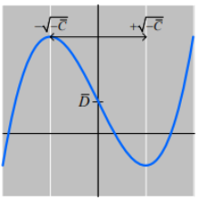

Чтобы квадратный корень имел смысл, нужно убедиться в отрицательности $\overline{C}$ при условии $\Delta > 0$. Она следует из уравнения syzygy: $$4\overline{C}^3=-\tilde{A}^2\Delta - \overline{D}^2.$$

Далее делается попытка тригонометрической замены. Мы хотим выявить взаимосвязь между $\tilde{x}$ и $cos\theta$ и провести аналогию между $(5.1)$ и $$4cos^3\theta-3cos\theta-cos3\theta=0 \quad\quad\quad(5.4)$$

Делая предположение, что в результате мы получим равенство $\tilde{x} = cos\theta$, нам необходимо поместить все корни в интервал $(-1;1)$.

Иными словами, нам необходимо сжать кривую по оси Ох, чтоб поместить корни трехчлена ближе к центру координат. Для этого выполним замену: $$\tilde{x}=2\sqrt{-\overline{C}}\tilde{\tilde{x}}.$$

Подставляя данное выражение в уравнение $(5.1)$, получим: $$(2\sqrt{-\overline{C}}\tilde{\tilde{x}})^3 + 3\overline{C}(2\sqrt{-\overline{C}}\tilde{\tilde{x}}) + \overline{D} = 0,$$ $$-8\overline{C}\sqrt{-\overline{C}}\tilde{\tilde{x}}^3 + 6\overline{C}\sqrt{-\overline{C}}\tilde{\tilde{x}} + \overline{D} = 0.$$

Делим все коэффициенты на $-2\overline{C}\sqrt{-\overline{C}}$: $$4\tilde{\tilde{x}}^3-3\tilde{\tilde{x}}+\frac{\overline{D}}{-2\overline{C}\sqrt{-\overline{C}}}=0.$$

Теперь необходимо убедиться, что $\frac{\overline{D}}{-2\overline{C}\sqrt{-\overline{C}}}$ меньше единицы по модулю. Это также следует из уравнения syzygy: $$-4\overline{C}^3=\tilde{A}^2\Delta + \overline{D}^2.\quad\quad(4.5)$$

$$\overline{D}^2<-4\overline{C}^3,$$$$\frac{\overline{D}^2}{-4\overline{C}^3} = (\frac{\overline{D}}{\sqrt{-4\overline{C}^3}})^2<1.$$

Равенство $(4.5)$ можно рассматривать как запись теоремы Пифагора, тогда:

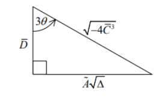

Для того, чтобы найти оставшиеся корни, Джеймс Блинн приводит иллюстрацию, на которой показывает все случаи расположения графика многочлена с тремя действительными различными корнями:

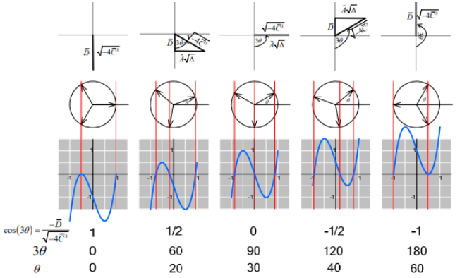

Когда $\theta$ пробегает от 0° до 60°, график пересекает ось Ох в трех точках. Каждому графику сопоставляется единичная окружность с тремя векторами из центра координат. Углы между векторами фиксированы и равны 120°. Сумма этих векторов обнуляется так же как и сумма корней кубического многочлена. Из графиков получаем выражения для корней:

$$\tilde{\tilde{x}}_1=cos\theta,$$$$\tilde{\tilde{x}}_2=cos(\theta-120°),$$$$\tilde{\tilde{x}}_3=cos(\theta+120°).$$

При подстановке этих выражений в уравнение $(5.4)$ можно убедиться в их правильности. Формулы можно преобразовать с помощью формул для косинуса суммы и косинуса разности:

$$\tilde{\tilde{x}}_1=cos\theta,$$$$\tilde{\tilde{x}}_2=-\frac{1}{2}cos\theta+\frac{\sqrt{3}}{2}sin\theta,$$$$\tilde{\tilde{x}}_3=-\frac{1}{2}cos\theta-\frac{\sqrt{3}}{2}sin\theta.$$

Пользуясь тем, что сумма корней равна нулю, перепишем:

$$\tilde{\tilde{x}}_1=cos\theta,$$$$\tilde{\tilde{x}}_2=-\frac{1}{2}cos\theta+\frac{\sqrt{3}}{2}sin\theta,$$$$\tilde{\tilde{x}}_3=-\tilde{\tilde{x}}_1-\tilde{\tilde{x}}_2.$$

Вернемся к тильда-пространству:

$$\tilde{x}_1=2\sqrt{-\overline{C}}cos\theta,$$$$\tilde{x}_2=2\sqrt{-\overline{C}}(-\frac{1}{2}cos\theta+\frac{\sqrt{3}}{2}sin\theta),\quad(5.5)$$$$\tilde{x}_3=2\sqrt{-\overline{C}}(-\tilde{\tilde{x}}_1-\tilde{\tilde{x}}_2).$$

### Уравнение типа 3

Для кубического полинома с корнем кратности 3 из таблицы 1: $\delta_1=\delta_2=\delta_3=0$.

Это значит, что $\Delta =\overline{C}=\overline{D}=0$.

Если подставить данные значения в уравнения $(4.4)$ для корней, полученные из тождества Ферро и Тарталья, можно получить $p = q = 0$.

Тогда $\tilde{x}_1=\tilde{x}_2=\tilde{x}_3=0$.

Если использовать тригонометрические формулы $(5.5)$, то корни также обнулятся, так как $\overline{C}=0$.

Тем не менее, после этапа undepressing нулевой корень встает на своё место в оригинальном пространстве.

### Блок-схема

Таким образом, мы рассмотрели все возможные случаи решения кубического многочлена. Составим блок-схему решения.

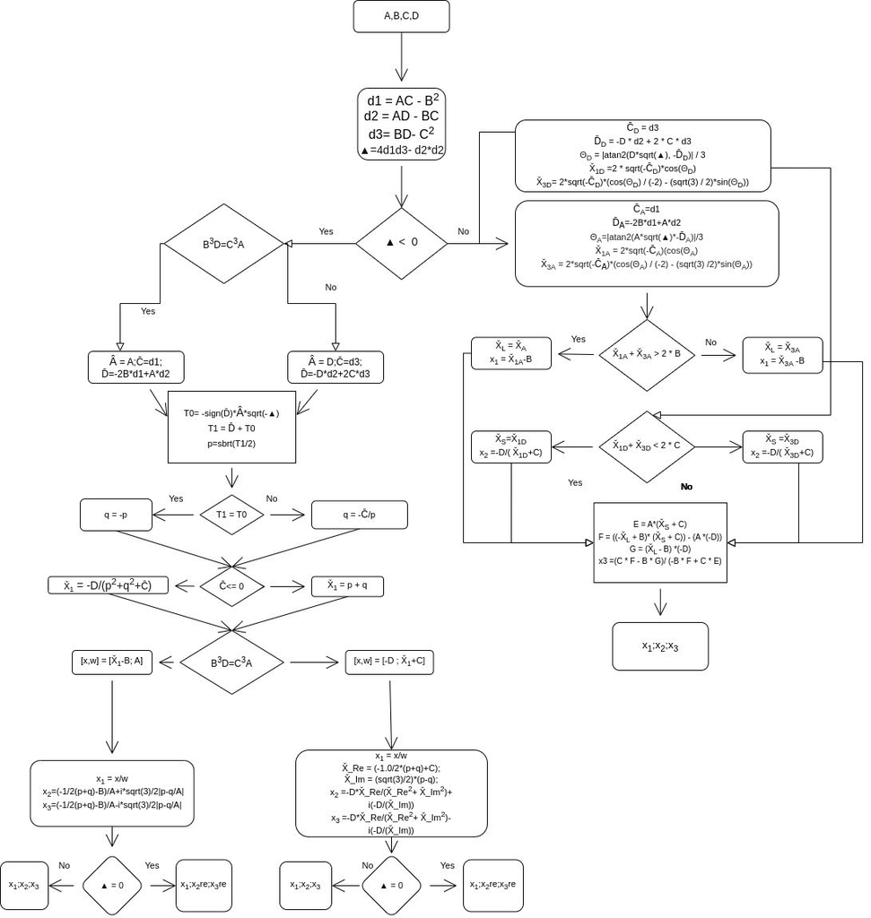